# Data Visualization I

Lab 1

Dr. Irene Vrbik

Last updated: January, 2024

In this lab, we will go through the plots created in Lectures [1](https://irene.quarto.pub/data-visualization/lecture1_python.html#/title-slide) and [2](https://irene.quarto.pub/data-visualization/lecture2.html#/title-slide), this time, using `ggplot` in R. The corresponding Altair code can be found within the lecture slide decks.

## ggplot

First and foremost let’s load the necessary packages. Obviously, we’ll need **ggplot2** but as seen below, this is automatically loaded alongside the **tidyverse** library (which will be used for data wrangling).

```r
library(tidyverse)
```

### Basic syntax

Every **ggplot2** plot has three key components:

1. **data** in “tidy” format (first argument in `ggplot`)
2. A set of **aesthetic mappings** between variables in the data and visual properties (eg. `x`, `y`, `colour`[^1], `shape`, `size`), and (set in [`aes`](https://ggplot2.tidyverse.org/reference/aes.html))
3. At least one layer which describes how to render each observation.
   - Usually created with a [**`geom`**](https://ggplot2.tidyverse.org/reference/#geoms) function.
   - Sometimes spcified with a [`stat_*`](https://ggplot2.tidyverse.org/reference/#stats) function (or `geom` is specified with a `stat` argument). See Statistical Summaries section below

A common basic syntax has the form:

```r
ggplot(<df>, aes(x = <var1>, y = <var2>)) +
  geom_*()
```

where:

- `df` is a “tidy” data frame
- `var1` is the desired column (i.e. feature/variable) from `df`
- `var2` is the desired column (i.e. feature/variable) from `df`
- and `geom_*` is a geometric object (often corresponding to a plot type eg. `geom_area` for area plots, `geom_points` for scatter plots)
  - the basic choices can be found [here (ggplot2-book)](https://ggplot2-book.org/individual-geoms.html)
  - a complete list of choices [here](https://ggplot2.tidyverse.org/reference/#geoms))

N.B. It is recommended in the [ggplot2 book](https://ggplot2-book.org/getting-started.html#basic-use) that each command appear on a new line for readability

### Modify main, axis and legend titles

The functions below can be used to modify plot titles (main title, axis labels and legend titles) using R software and ggplot2 package.

```r
ggtitle(label) # for the main title
xlab(label) # for the x axis label
ylab(label) # for the y axis label
labs(...) # for the main title, axis labels and legend titles
```

### Statistical Summaries

When we need to plot summary statistics in a ggplot we could of course wrangle the data outside of the plotting function. However, we should try and make sure of the shortcuts available to us directly within `ggplot()`. Similar to the aggregation functions used in Altair, we can create new variables using statistical transformations, or **stats**, via `stat_*` functions; see complete list [here](https://ggplot2-book.org/layers.html?q=stat_#stat).

Some of these functions won’t be called directly, but rather used “under the hood” to generate many important geoms. For example, `stat_bin` is used to make histogram and it produces the following variables:

- `count`, the number of observations in each bin
- `density`, the density of observations in each bin (percentage of total / bar width)
- `x`, the centre of the bin

When we do use these functions directly, we call call them in two different ways: You can either

- add a `stat_()` function and override the default geom, or
- add a `geom_()` function and override the default stat

You can see an example using `stat_summary` down below

## Data sets

### Cars

This was the 1983 ASA Data Exposition dataset. The dataset was collected by Ernesto Ramos and David Donoho and contains a label plus 8 variables for 406 different cars. The data contains NaNs in several records. The original cars.data archive was retrieved from StatLib, the Datasets Archive located at http://lib.stat.cmu.edu/datasets

```r
cars_url = "https://raw.githubusercontent.com/sandialabs/slycat-data/master/cars.csv"
cars <- read.csv(cars_url)
attach(cars)
head(cars)
```

|  | Model | MPG | Cylinders | Displacement | Horsepower | Weight | Acceleration | Year | Origin |
| --- | --- | --- | --- | --- | --- | --- | --- | --- | --- |
| 1 | chevrolet chevelle malibu | 18 | 8 | 307 | 130 | 3504 | 12.0 | 70 | 1 |
| 2 | buick skylark 320 | 15 | 8 | 350 | 165 | 3693 | 11.5 | 70 | 1 |
| 3 | plymouth satellite | 18 | 8 | 318 | 150 | 3436 | 11.0 | 70 | 1 |
| 4 | amc rebel sst | 16 | 8 | 304 | 150 | 3433 | 12.0 | 70 | 1 |
| 5 | ford torino | 17 | 8 | 302 | 140 | 3449 | 10.5 | 70 | 1 |
| 6 | ford galaxie 500 | 15 | 8 | 429 | 198 | 4341 | 10.0 | 70 | 1 |

## (Re)creation of plots from Lecture 1

Recall the connections we made between Altair’s syntax and ggplot’s:

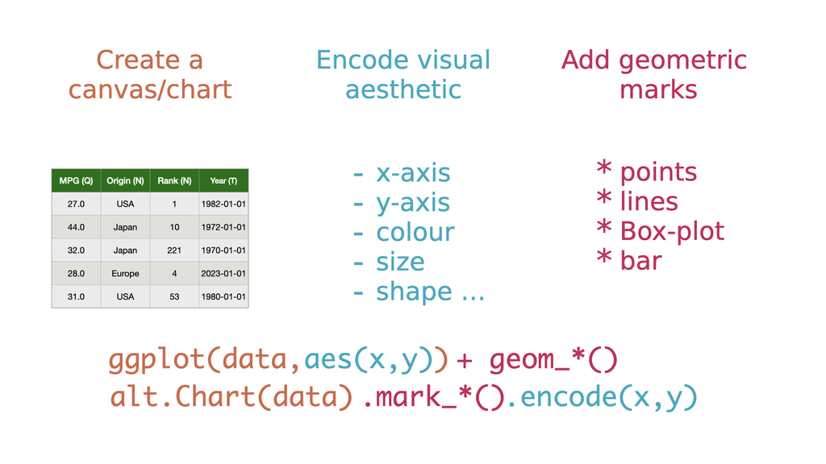

### Scatter plot

#### Mapping colour to a continuous feature

We will attempt to recreate this plot:

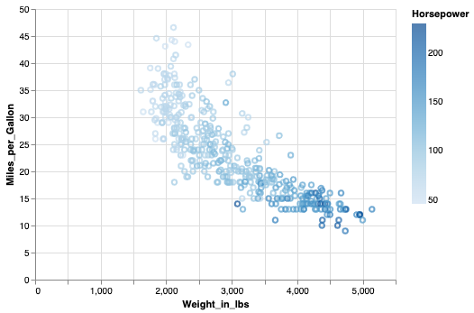

Recall the Altair code:

```python
# code in Python's Altair (not run in R)
alt.Chart(cars).mark_point().encode(
    x='Weight_in_lbs',
    y='Miles_per_Gallon',
    color='Horsepower')
```

Before unfolding the code below by pressing the “CODE” button on the right-hand size, attempt it for yourself! (Note that some of the column names are slightly different from the vega data set we imported in Python)

```
## Warning: Removed 8 rows containing missing values (`geom_point()`).
```

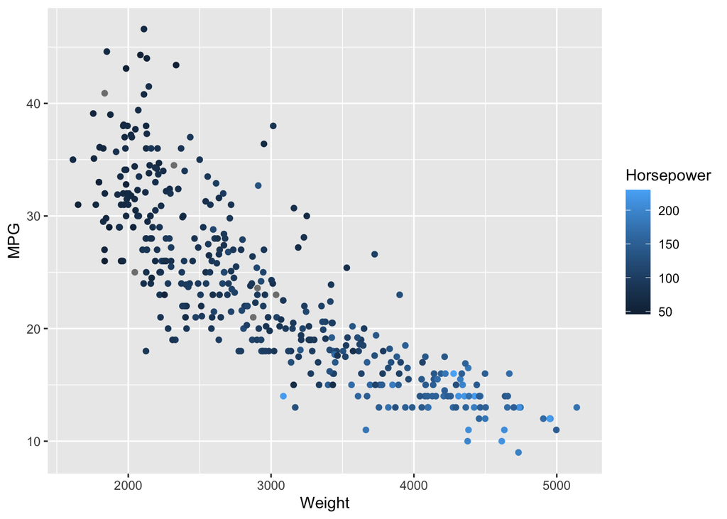

```r
ggplot(cars, aes(x = Weight, y = MPG, color = Horsepower)) +
  geom_point()
```

Notice that there are slight differences in the default behaviour of `ggplot` vs. Altair. Apart from general “themes” (ggplot uses a gray background and filled points), Altair includes the origin (0,0) whereas `ggplot` extends the axes only to the range of the data points. Also, R gives us a warning that it removes a number of row containing missing values. While this is a nice feature, I will suppress this warning (using `warning = FALSE` in the following chunks).

#### Mapping colour to a categorical feature

We will attempt to recreate this plot:

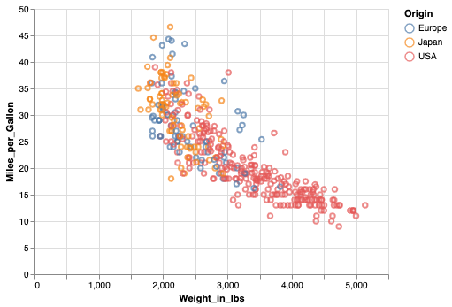

Recall the Altair code:

```python
# code in Python's Altair (not run in R)
alt.Chart(cars).mark_point().encode(
    x='Weight_in_lbs',
    y='Miles_per_Gallon',
    color='Origin')
```

Before unfolding the code below by pressing the “CODE” button on the right-hand size, attempt it for yourself! Hint: you will need to change the data type of `Origin`.

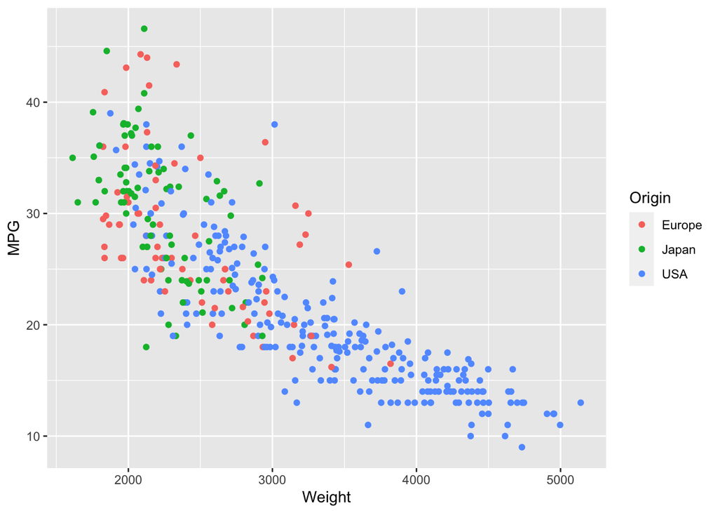

```r
## Solution (output and warnings suppressed to save space)
cars$Origin <- factor(cars$Origin, levels = c(2,3,1), labels = c("Europe",  "Japan", "USA"))
ggplot(cars, aes(x = Weight, y = MPG, color = Origin)) +
  geom_point()
```

### Line plots

#### Running average over time

We will attempt to recreate this plot:

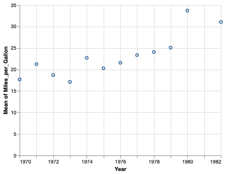

Recall the Altair code:

```python
# code in Python's Altair (not run in R)
alt.Chart(cars).mark_point().encode(
    x='Year',
    y='mean(Miles_per_Gallon)')
```

I don’t expect you to be able to get at this one without some guidance, so let’s walk through it together. First recall that this is what our data for these two variables look like:

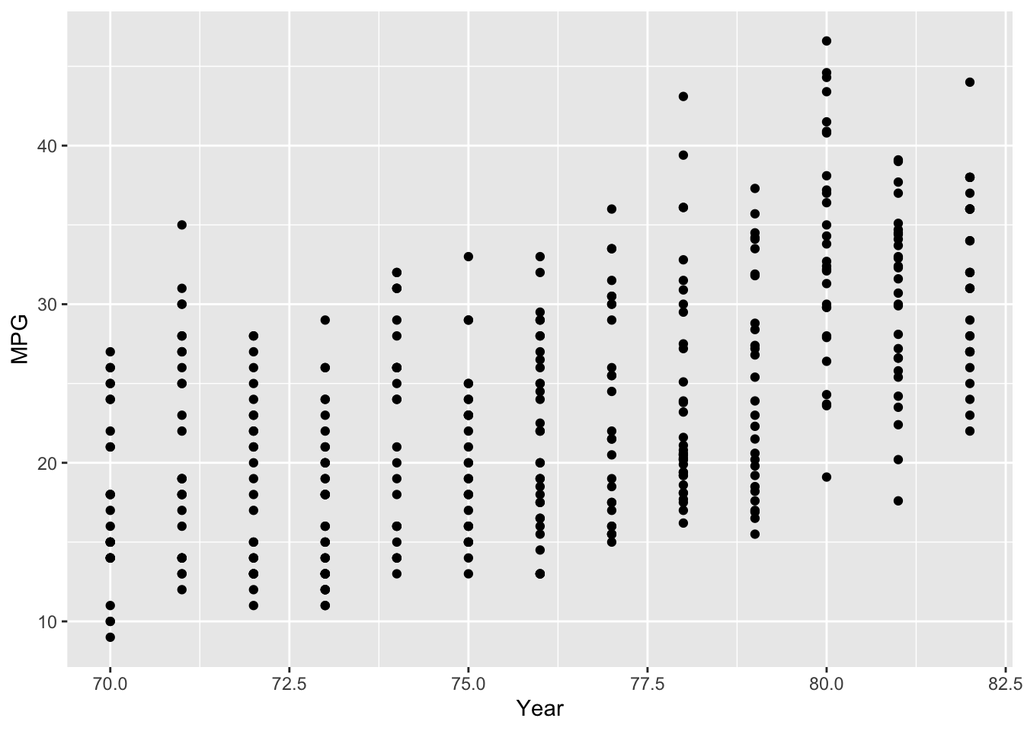

```r
ggplot(cars, aes(x = Year, y = MPG)) +
  geom_point()
```

What we need to do if first *summarize* the y values at distinct x values using the `stat_summary()` function (read documentation [here](https://ggplot2.tidyverse.org/reference/stat_summary.html) and the Statistical Summaries section above). In this function will need to specify `fun`, which function we’d like to apply to these y values (in this case the mean() function); and `geom`, which geometric object, aka marking, we’d like to display the data with (in this case “point”)

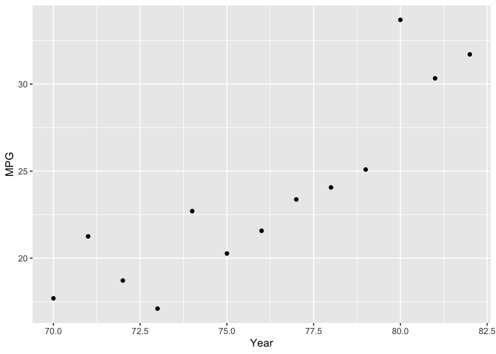

```r
ggplot(cars, aes(x = Year, y = MPG)) +
  stat_summary(fun = mean, geom = "point")
```

As stated before, Altair’s default is slightly different in that it includes the origin in this plot. Alternatively/equivalently we could have used:

```r
# output suppressed to save space
ggplot(cars, aes(x = Year, y = MPG)) +
  geom_point(stat = "summary", fun = mean)
```

To superimpose points overtop of the line as done in the example below:

We will attempt to recreate this plot:

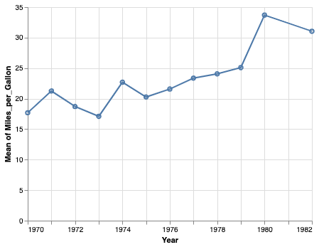

Recall the Altair code:

```r
line = alt.Chart(cars).mark_line().encode(
    x='Year',
    y='mean(Miles_per_Gallon)')

line + line.mark_point()
```

we could use …

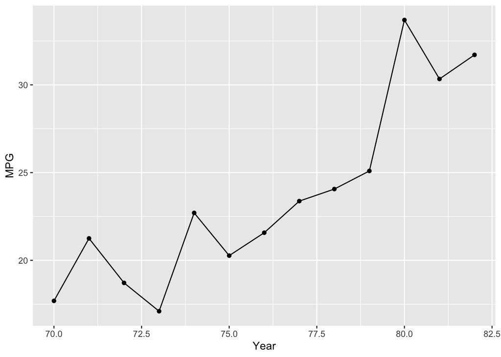

```r
ggplot(cars, aes(x = Year, y = MPG)) +
  geom_point(stat = "summary", fun = mean) +
  geom_line(stat = "summary", fun = mean)
```

We will attempt to recreate this plot:

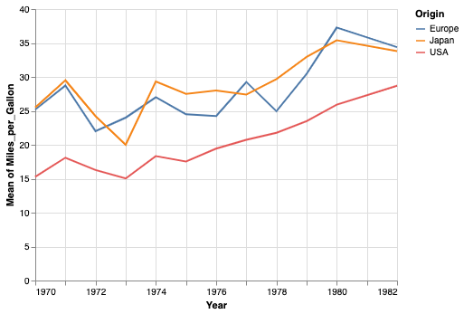

Recall the Altair code:

```python
# code in Python's Altair (not run in R)
alt.Chart(cars).mark_line().encode(
    x='Year',
    y='mean(Miles_per_Gallon)',
    color='Origin')
```

Try to adapt the above code in order to recreate this plot in R. While the answer can be unfolded below, do try it out before you click!

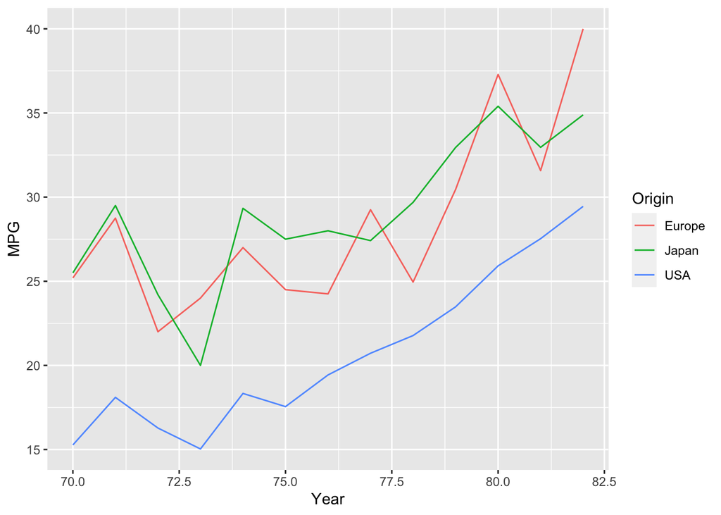

```r
ggplot(cars, aes(x = Year, y = MPG, colour = Origin)) +
  geom_line(stat = "summary", fun = mean) # or
```

```r
 # stat_summary(fun = mean, geom = "line")
```

*Question: let’s see if you can use the multiple concepts above to create this:*

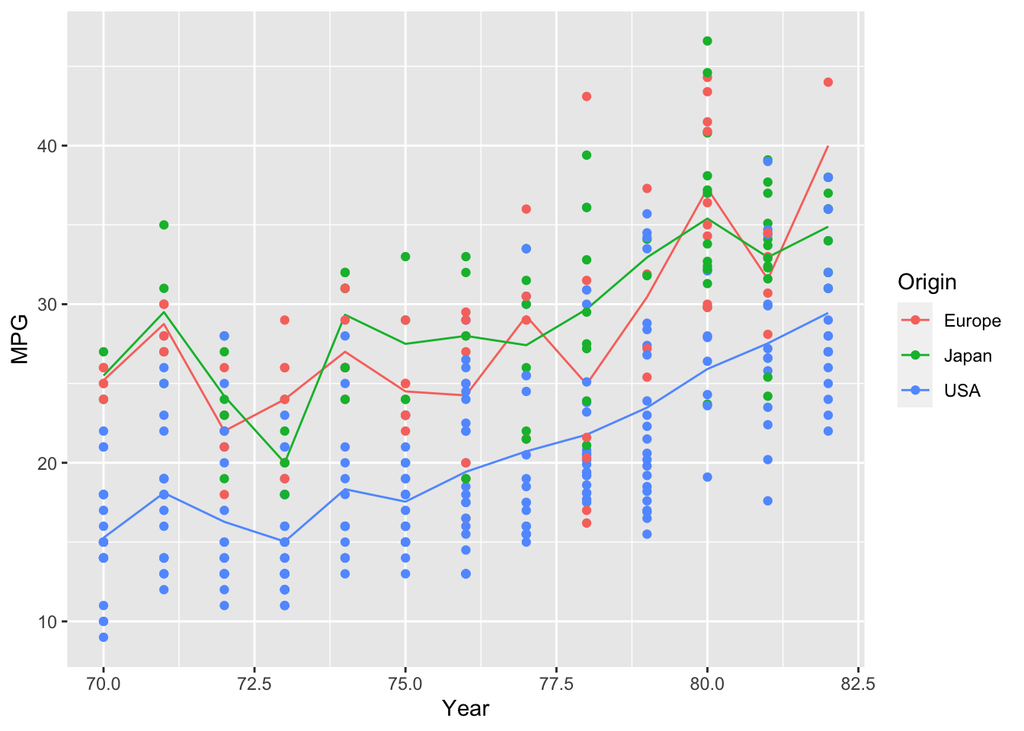

[^1]: colour can be spelled with or without the “u”. Altair only accepts the American spelling “color”